# Statistical Inference

Curry W. Hilton

# Estimation of Parameters

Recall, parameters are descriptors of the population, such as mean ($\mu$), variance ($\sigma^2$), standard deviation ($\sigma$), etc. Such measures explain a set of information regarding a population. For example, all the students enrolled at the University of Alabama would represent a population of $N =$ 36,155 in 2014. We might be interested in understanding the mean age of all enrolled students to better understand the central tendency of the distribution. Other such population parameters could be derived…when population sizes are relatively large, obtaining and measuring population parameters can be quite challenging. So…We SAMPLE!

## Point Estimates (Statistics)

| Parameter | Statistic | Function |
| --- | --- | --- |
| Mean ($\mu$) | Sample Mean ($\bar{x}$) | $\bar{x}=\frac{1}{n}\displaystyle\sum\limits_{i=1}^nx_i$ |
| Standard Deviation ($\sigma$) | Sample Standard Deviation ($s$) | $s = \sqrt{\frac{\displaystyle\sum\limits_{i=1}^n(x_i-\bar{x})^2}{n-1}}$ |
| Proportion ($p$) | Sample Proportion ($\bar{p}$) | $\bar{p} = \frac{x}{n}$ |

## Sampling

Random sampling will be the only means of sampling utilized in this course. Basically, when random sampling each observation in the population has an equal chance of being selected in the generated sample.

```r
?sample
sample(x, size, replace = FALSE, prob = NULL)
```

### Example 1

Load the “possum” dataset from the openintro package into your Global Environment (We will assume this represents the population of possums!).

```r
library(openintro)
data(possum)
```

Observe the population distribution of possums’ tail lengths in a histogram. What does the distribution resemble?

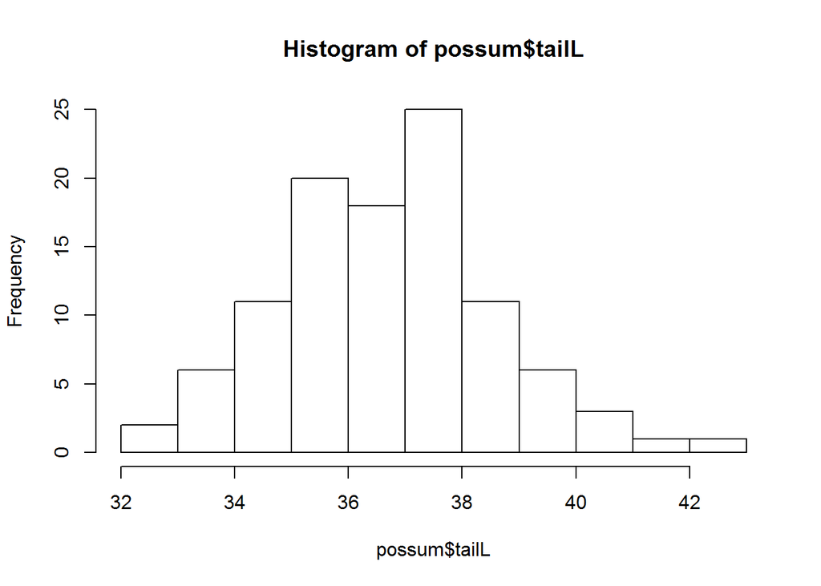

```r
hist(possum$tailL)
```

What are the population parameters for mean and standard deviation?

```r
mean(possum$tailL)
```

```
## [1] 37.00962
```

```r
sd(possum$tailL)
```

```
## [1] 1.959518
```

Let’s take a sample of 5 observations from the population of possum tails! Call the sample, “samp1”.

```r
set.seed(1234)
samp1 <- sample(possum$tailL, 5)
samp1
```

```
## [1] 35.5 38.0 38.0 38.0 41.5
```

Observe the sample distribution by means of a histogram of “samp1”.

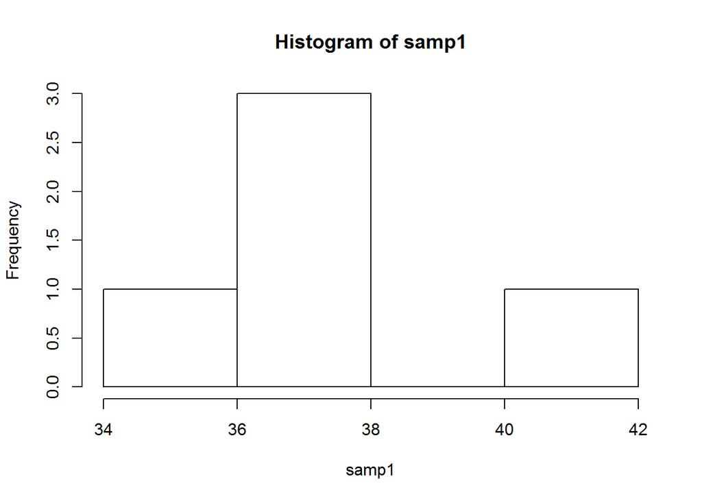

```r
hist(samp1)
```

What are the sample statistics for mean and standard deviation of “samp1”?

```r
mean(samp1)
```

```
## [1] 38.2
```

```r
sd(samp1)
```

```
## [1] 2.138925
```

How close are the sample statistics and population parameters? Are the sample statistics fair representations of the population parameters? What are we doing?!?…statistical inference! Whoop Whoop!

How could we improve our inference regarding the population? Wait for it…increase your sample size!

### Example 2

Use the same information from the above Example 1. Now let’s take a sample of 30 observations from the population and call it “samp2”.

```r
set.seed(1234)
samp2 <- sample(possum$tailL, 30)
samp2
```

```
##  [1] 35.5 38.0 38.0 38.0 41.5 38.5 36.0 36.0 38.5 37.0 36.5 36.0 35.0 40.5
## [15] 37.0 38.0 36.0 34.0 36.5 38.0 38.5 38.0 36.0 38.0 36.0 36.5 32.0 40.0
## [29] 38.0 38.0
```

Examine the histogram of “samp2”. Does it look more like the distribution of the population in comparison to samp1?

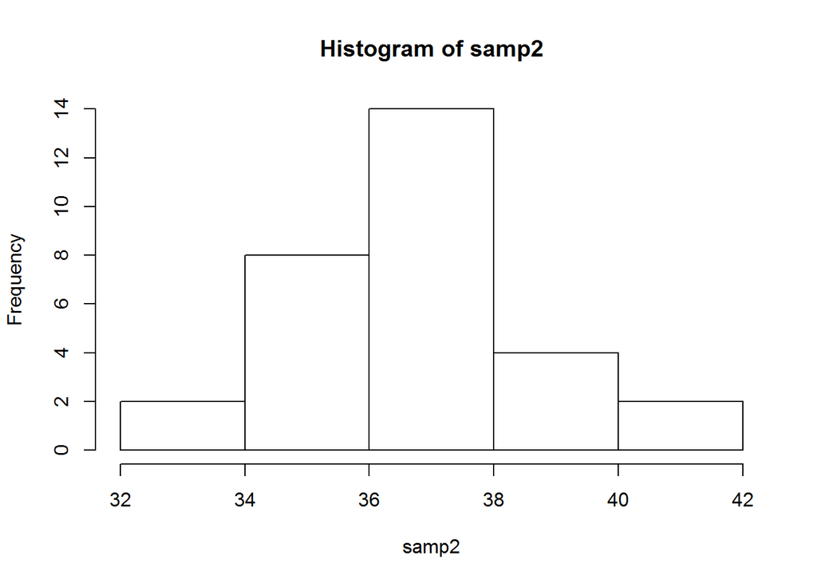

```r
hist(samp2)
```

What are the sample statistics for mean and standard deviation of “samp2”?

```r
mean(samp2)
```

```
## [1] 37.18333
```

```r
sd(samp2)
```

```
## [1] 1.886811
```

Did the sample statistics improve or converge closer to the population parameters as the number of observations in the sample increase?

## Sampling Distributions

Represents the distribution of statistics from samples of fixed sizes from a population. For example, if I were to take 25 samples of size 10 from a population, calculate the sample mean from each sample, and create a histogram, I would be creating a sampling distribution for the sample mean.

### Example 3

Use the “possum” dataset and let’s examine the variable ‘headL’. Take 30 samples of size 15 from the population of possums. You will **not** be responsible for generating the code below yourself.

```r
s_dist <- rep(NA, 30)
for (i in 1:30) {
  set.seed(i)
    samp3 <- sample(possum$headL, 15)
    s_dist[i] <- mean(samp3)
}
```

Create a histogram of the sampling distribution for the sample mean of possum head length.

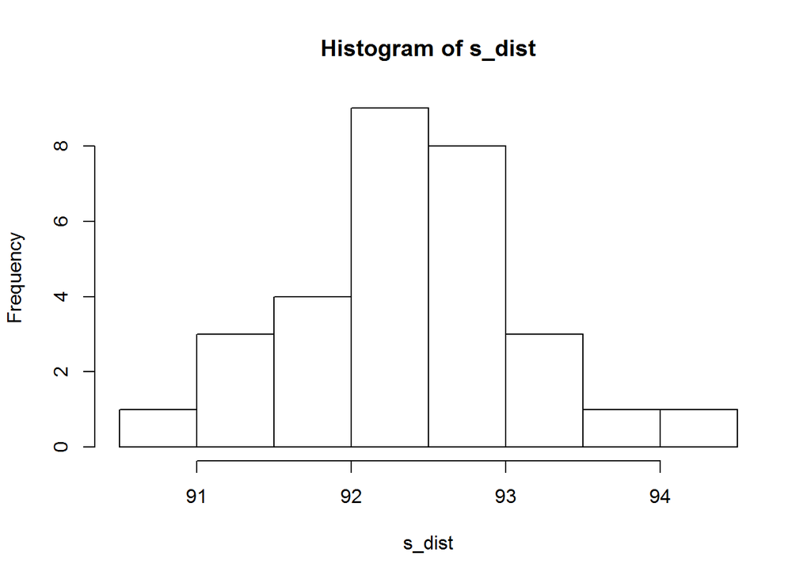

```r
hist(s_dist)
```

What is the mean of the population of all possums’ head lengths? What is the mean of all the sample means in the sampling distribution?

```r
mean(possum$headL)
```

```
## [1] 92.60288
```

```r
mean(s_dist)
```

```
## [1] 92.39489
```

Getting close! This is what is considered proof of unbiasedness in estimates. We will not cover unbiasedness or convergence in this course…

### Standard Error of Estimates (SE)

The standard deviation associated with the estimate. Basically, a means to describe the error of the sample statistic.

Standard error of a sample mean…

$$SE = \frac{\sigma}{\sqrt{n}}$$

Where, $n$ is the number of observations in the sample and $\sigma$ is the standard deviation of the population. When the population standard deviation is not known, we *usually* can use the sample standard deviation ($s$) if the number of observations in the sample is $n \geq 30$.

### Example 4

Calculate the population mean and standard deviation for the ‘skullW’ variable from the “possum” dataset.

```r
mean(possum$skullW)
```

```
## [1] 56.88365
```

```r
sd_p <- sd(possum$skullW)
sd_p
```

```
## [1] 3.113426
```

Take a sample of 30 possums from the population using ‘skullW’ as the variable of interest and name it ‘samp4’.

```r
set.seed(1986)
samp4 <- sample(possum$skullW, 30)
samp4
```

```
##  [1] 59.6 58.5 56.4 55.7 57.7 55.8 67.7 52.4 57.6 53.2 56.1 58.5 52.0 63.0
## [15] 55.2 51.5 54.8 56.2 55.6 56.3 55.7 55.4 57.9 54.4 55.0 53.8 56.0 62.8
## [29] 56.0 61.0
```

Derive the mean, standard deivation, and standard error (use the population standard deviation and the sample standard deviation) associated with the sample mean statistic for ‘samp4’.

```r
mean(samp4)
```

```
## [1] 56.72667
```

```r
sd_s <- sd(samp4)
sd_s
```

```
## [1] 3.446031
```

```r
se_p <- sd_p/sqrt(30)
se_p
```

```
## [1] 0.5684312
```

```r
se_s <- sd_s/sqrt(30)
se_s
```

```
## [1] 0.6291562
```

# Confidence Intervals

Represents a range of values of possible values for the parameter estimate. So instead of offering a point estimate, say the sample mean, as the only representation of the population mean, $\mu$, we offer an interval of values that the population parameter could be. I like the example in the book…when fishing you are more likely to catch a fish with a net than throwing a spear.

To ensure we capture the true population parameter we need to develop an interval of potential values for certain levels of confidence. Confidence intervals are created around the most “likely” estimate of the population parameter. For example, if we are estimating the population mean ($\mu$) we will use the sample mean ($\bar{x}$) as the center of the confidence interval.

Correct interpretation of *confidence intervals*: We are xx% confident that true population parameter is between x and y.

Where, $\sigma$ of the population is *known*

$$Point_{Estimate} \pm z_{\frac{\alpha}{2}}\frac{\sigma}{\sqrt{n}}$$

Where, $\sigma$ of the population is *unknown*

$$Point_{Estimate} \pm t_{\frac{\alpha}{2}}\frac{s}{\sqrt{n}}$$

## Margin of Error (MOE)

$$MOE_z = z_{\frac{\alpha}{2}}\frac{\sigma}{\sqrt{n}}$$

$$MOE_t = t_{\frac{\alpha}{2}}\frac{s}{\sqrt{n}}$$

## Common Confidence Levels (z)

Keep in mind these are two-sided intervals!

| Confidence Levels (1-$\alpha$) | Levels of Significance ($\alpha$) | $z_{\frac{\alpha}{2}}$ |
| --- | --- | --- |
| 90% - 0.90 | 10% - 0.1 | $\pm 1.645$ |
| 95% - 0.95 | 5% - 0.05 | $\pm 1.960$ |
| 99% - 0.99 | 1% - 0.01 | $\pm 2.576$ |

z-scores in R

```r
qnorm(0.1/2, 0, 1, lower.tail = FALSE)    # 90% z-score
```

```
## [1] 1.644854
```

```r
qnorm(0.05/2, 0, 1, lower.tail = FALSE)   # 95% z-score
```

```
## [1] 1.959964
```

```r
qnorm(0.01/2, 0, 1, lower.tail = FALSE)   # 99% z-score
```

```
## [1] 2.575829
```

## Common Confidence Levels (t, df)

The t-distribution takes on multiple values depending on degrees for freedom (df), where $df = n-1$.

R function with arguments for t-distribution

*qt(p, df, ncp, lower.tail = TRUE, log.p = FALSE)*

```r
qt(0.1/2, 10, lower.tail = FALSE)       # 90% t-score with 10 df
```

```
## [1] 1.812461
```

```r
qt(0.1/2, 15, lower.tail = FALSE)       # 90% t-score with 15 df
```

```
## [1] 1.75305
```

```r
qt(0.1/2, 20, lower.tail = FALSE)       # 90% t-score with 20 df
```

```
## [1] 1.724718
```

```r
qt(0.05/2, 10, lower.tail = FALSE)      # 95% t-score with 10 df
```

```
## [1] 2.228139
```

```r
qt(0.05/2, 15, lower.tail = FALSE)      # 95% t-score with 15 df
```

```
## [1] 2.13145
```

```r
qt(0.05/2, 20, lower.tail = FALSE)      # 95% t-score with 20 df
```

```
## [1] 2.085963
```

### Example 1: Population Standard Deviation Known ($\sigma$)

Use the dataset “rock” and variable of interest ‘area’. Assume this represents the entire population.

Examine the histogram of the ‘area’ variable. Does it appear to be distributed normally?

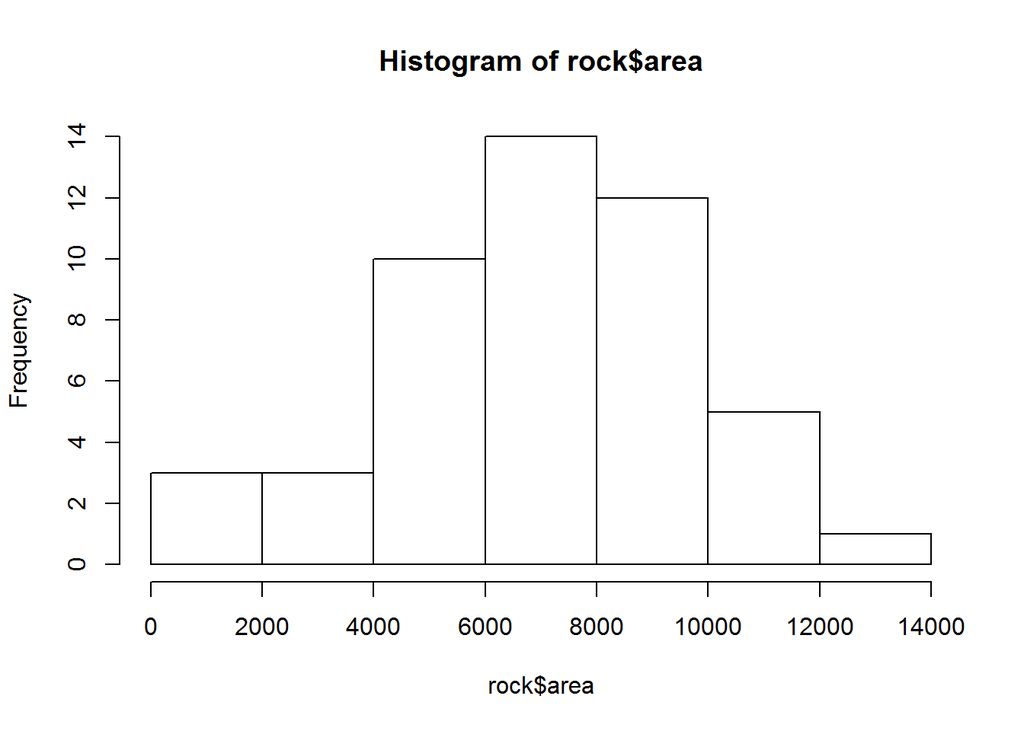

```r
hist(rock$area)
```

Calculate the mean and standard deviation of the population.

```r
mean(rock$area)
```

```
## [1] 7187.729
```

```r
sd(rock$area)
```

```
## [1] 2683.849
```

Now take a sample of size 25 from the population and name it ‘samp1’.

```r
set.seed(123)
samp1 <- sample(rock$area, 25)
samp1
```

```
##  [1]  8868  1468 11878  5267  1016  7002 12212  3469  8793 10743  5048
## [12] 10962  6360  7838  7352  4895  8209  5605  6425  5246  7894  1651
## [23]  5514  6509  8874
```

Determine the 95% Confidence Interval of the sample mean of ‘samp1’.

```r
x_bar <- mean(samp1)                                   # calculate sample mean
x_bar
```

```
## [1] 6763.92
```

```r
se <- 2683.849/sqrt(25)                                # calculate standard error
se
```

```
## [1] 536.7698
```

```r
z <- qnorm(0.05/2,0,1, lower.tail = FALSE)             # z-score associated with 95% CI
z
```

```
## [1] 1.959964
```

```r
moe <- z*se                                            # calculate moe
moe
```

```
## [1] 1052.049
```

```r
ci <- x_bar + (c(-1,1)*moe)                            # calculate confidence interval
ci
```

```
## [1] 5711.871 7815.969
```

Mathematically Approach:

$$\sigma_{pop} = 2683.849$$

$$z_{\frac{\alpha}{2}} = 1.96$$

$$MOE_z = z_{\frac{\alpha}{2}}\frac{\sigma}{\sqrt{n}} = 1.96(\frac{2683.849}{\sqrt{25}})=1052.069$$

### Example 2: Population Standard Deviation Unknown ($\sigma$)

Use the dataset “run10” and variable of interest ‘time’. Assume this is population data but not fully represented…

Examine the histogram of the ‘time’ variable. Does it appear to be distributed normally?

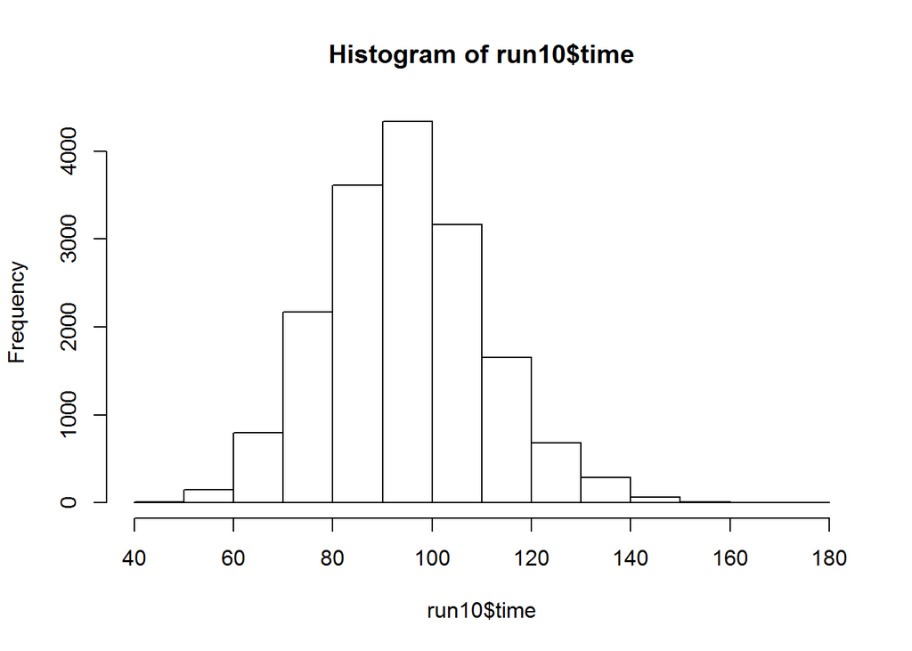

```r
hist(run10$time)
```

Since the ‘run10’ dataset does not fully account for the entire population, the population mean ($\mu$) and population standard deviation ($\sigma$) cannot be calculated.

Now take a sample of size 25 from the population and name it ‘samp2’.

```r
library(openintro)
set.seed(189)
samp2 <- sample(run10$time, 25)
samp2
```

```
##  [1]  98.72  99.42 107.20 101.47  90.82  70.38  84.08  89.78  74.68  73.70
## [11]  79.05  92.37  95.67  98.72  97.20  74.60 113.65 112.33  96.57  94.50
## [21] 103.30  70.30  71.87 119.33 100.75
```

Determine the 95% Confidence Interval of the sample mean of ‘samp2’.

```r
x_bar <- mean(samp2)                                   # calculate sample mean
x_bar
```

```
## [1] 92.4184
```

```r
s <- sd(samp2)                                         # sample standard deviation
s
```

```
## [1] 14.26041
```

```r
se <- 14.26041/sqrt(25)                                # calculate standard error
se
```

```
## [1] 2.852082
```

```r
t <- qt(0.05/2, 24, lower.tail = FALSE)                # t-score associated with 95% CI; df=24
t
```

```
## [1] 2.063899
```

```r
moe <- t*se                                            # calculate moe
moe
```

```
## [1] 5.886408
```

```r
ci <- x_bar + (c(-1,1)*moe)                            # calculate confidence interval
ci
```

```
## [1] 86.53199 98.30481
```

Mathematically Approach:

$$\bar{x} = 92.4184$$

$$s = 14.26041$$

$$t_{\frac{\alpha}{2}} = 2.0638$$

$$MOE_t = t_{\frac{\alpha}{2}}\frac{s}{\sqrt{n}} = 2.0638(\frac{14.26041}{\sqrt{25}})=5.886408$$

$$CI_{95} = \bar{x} \pm MOE = 92.4184 \pm 5.886408 = (86.53, 98.30)$$

# Central Limit Theorem (CLT)

Basically, the distribution of the sample mean can be approximated as normally distributed when the number of observations ($n$) within samples is large…rule of thumb $n \geq 30$.

Follow link provided below for demonstration of CLT for the distribution of sample mean.

https://gallery.shinyapps.io/CLT_mean/

### Example 3: CLT

Use the dataset “cars” and variable of interest ‘mpgCity’. Assume this represents the entire population.

Examine the histogram of the ‘mpgCity’ variable. Does it appear to be distributed normally? Ewww!

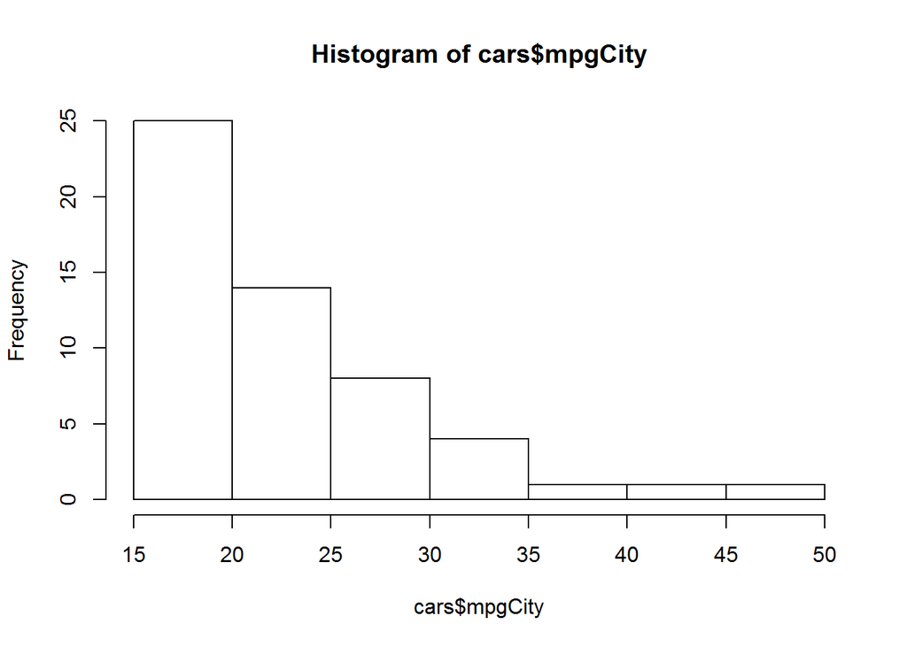

```r
hist(cars$mpgCity)
```

So…what do we do…

How can we make inferences about population parameters when the population distribution is not normal? Well…CLT, CLT, CLT!

Let’s prove this.

Take 100 random samples of size $n = 2$. Create a histogram and examine the distribution.

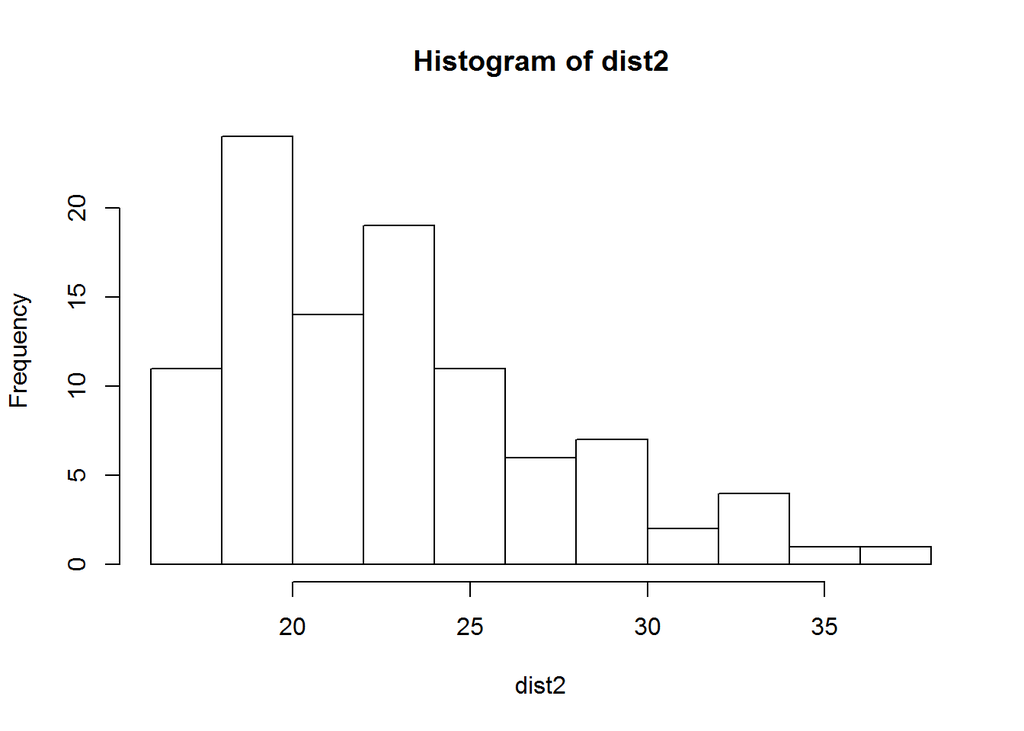

```r
dist2 <- rep(NA, 100)
for (i in 1:100) {
  set.seed(i)
    samp <- sample(cars$mpgCity, 2)
    dist2[i] <- mean(samp)
}
hist(dist2)
```

Take 100 random samples of size $n = 5$. Create a histogram and examine the distribution.

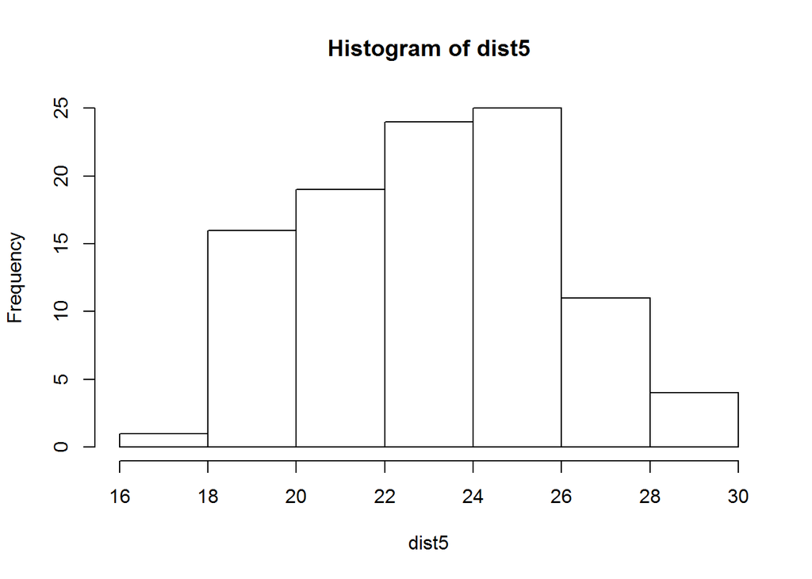

```r
dist5 <- rep(NA, 100)
for (i in 1:100) {
  set.seed(i)
    samp <- sample(cars$mpgCity, 5)
    dist5[i] <- mean(samp)
}
hist(dist5)
```

Take 100 random samples of size $n = 15$. Create a histogram and examine the distribution.

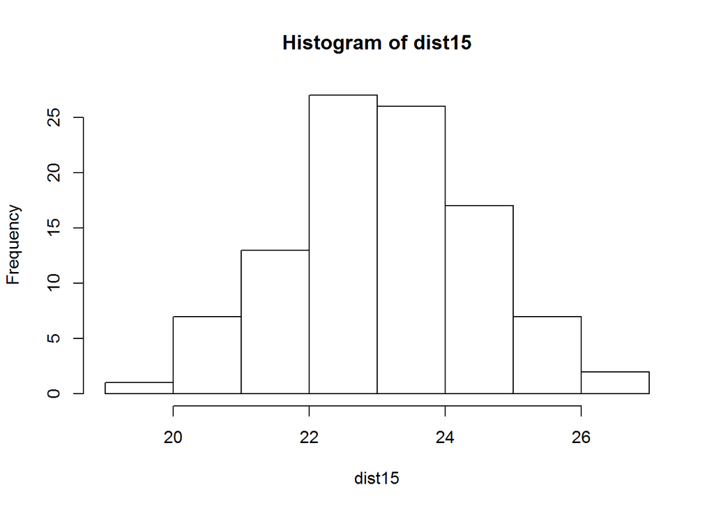

```r
dist15 <- rep(NA, 100)
for (i in 1:100) {
  set.seed(i)
    samp <- sample(cars$mpgCity, 15)
    dist15[i] <- mean(samp)
}
hist(dist15)
```

# Hypothesis Testing

Basically the scientific method to some degree…

Ask a question of interest, develop a hypothesis, analyze or observe an experiment, conclude on hypothesis. In statistics we use a similar structure for testing theoretical concepts with empirical findings.

“A hypothesis test is a statistical test that is frequently used to determine whether there is enough evidence in a sample of data to infer that a certain condition is true for the entire population” (Copyright 2015 Minitab Inc. All rights Reserved)

Great Resource for Hypothesis Testing in the following link:

http://support.minitab.com/en-us/minitab/17/topic-library/basic-statistics-and-graphs/hypothesis-tests/basics/what-is-a-hypothesis-test/

## Structure of Testing

*Null Hypothesis*: Represents a claim to be tested. Usually is the case that assumes no relationship or difference exists between testing groups or parameters. Usually comes from previously proven theory or experience. (Always has form of equivalence in the statement!)

$$H_0$$

*Alternative Hypothesis*: Also referred to as the “research” hypothesis. It is usually the contradiction to the null hypothesis and hoped to be proven acceptable through statistical testing.

$$H_A$$

## Hypothesis Testing Forms

| One-tail Upper | One-tail Lower | Two-tail Not Equal |
| --- | --- | --- |
| $H_0: \mu \leq \mu_0$ | $H_0: \mu \geq \mu_0$ | $H_0: \mu = \mu_0$ |
| $H_A: \mu > \mu_0$ | $H_A: \mu < \mu_0$ | $H_A: \mu \ne \mu_0$ |

### One-tail Greater Than

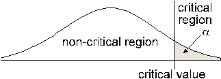

### One-tail Less Than

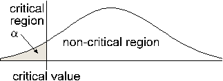

### Two-tailed Not Equal

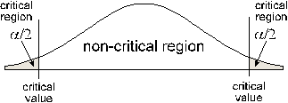

## Hypothesis Testing Steps

- State the “original claim” and determine if it is considered the Null or Alternative Hypothesis
- Write the Null and Alternative Hypothesis
- Using the Alternative Hypothesis identify the necessary type of test
- Draw the picture!!!! (including rejection zone(s))
- Find the critical value (computed)
- Make a decision to reject or fail to reject the null hypothesis
- State conclusion

## Type I and Type II Errors

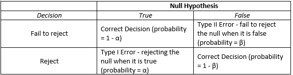

*Level of Significance* ($\alpha$): Probability of making a Type I error. Your willingness to accept a xx% chance of being wrong when you reject the null hypothesis.

*Power of the Test* ($1-\beta$): The probability of rejecting the null hypothesis when it is truly false.

## Critical Value

The quantile representing the level of significance ($\alpha$). See above sample distribution graphs for Hypothesis Testing Forms.

### One-Tailed Critical Values (Greater than or Less than) - $\sigma$ known

| Level of Significance ($\alpha$) | Hypothesis Test | Critical Value Lower | Critical Value Upper |
| --- | --- | --- | --- |
| 0.1 | z-test | -1.28 | 1.28 |
| 0.05 | z-test | -1.64 | 1.64 |
| 0.01 | z-test | -2.33 | 2.33 |

### Two-Tailed Critical Values (Equal to) - $\sigma$ known

| Level of Significance ($\frac{\alpha}{2}$) | Hypothesis Test | Critical Value Lower | Critical Value Upper |
| --- | --- | --- | --- |
| $\frac{0.1}{2} = 0.05$ | z-test | -1.64 | 1.64 |
| $\frac{0.05}{2} = 0.025$ | z-test | -1.96 | 1.96 |
| $\frac{0.01}{2} = 0.005$ | z-test | -2.58 | 2.58 |

### One-Tailed Critical Values (Greater than or Less than) - $\sigma$ unknown

qt(p, df, ncp, lower.tail = TRUE, log.p = FALSE)

```r
qt(0.05, 40, lower.tail = TRUE)      # t-critical value when alpha = 0.05 and df = 40 (lower tail test)
```

```
## [1] -1.683851
```

```r
qt(0.05, 40, lower.tail = FALSE)     # t-critical value when alpha = 0.05 and df = 40 (upper tail test)
```

```
## [1] 1.683851
```

qt(p, df, ncp, lower.tail = TRUE, log.p = FALSE)

```r
qt(0.05/2, 40, lower.tail = TRUE)      # t-critical value when alpha = 0.05 and df = 40 (two-sided tail test)
```

```
## [1] -2.021075
```

## Test Statistics for Population Means

A standardized statistic derived based on sample data collected for the test. Useful in providing evidence on whether to reject or fail to reject the test.

| $\sigma$ Known? | Hypothesis Test | Test Statistic |
| --- | --- | --- |
| Yes | z-test | $z = \frac{\bar{x}-\mu_0}{\frac{\sigma}{\sqrt{n}}}$ |
| No | t-test | $t = \frac{\bar{x}-\mu_0}{\frac{s}{\sqrt{n}}}$ |

### p-Value

The probability associated with the derived test statistic.

## Methods for Conducting Hypothesis Tests

### Critical Value Comparison

*Rejection Rules for $\sigma$ known and unknown*

| Test Statistic | Testing Type | Rejection $H_0$ if |
| --- | --- | --- |
| z | Upper-Tail | $z \geq z_{\alpha}$ |
| z | Lower-Tail | $z \leq -z_{\alpha}$ |
| z | Two-Tailed | $z \geq z_{\frac{\alpha}{2}}$ or $z \leq -z_{\frac{\alpha}{2}}$ |
| t | Upper-Tail | $t \geq t_{\alpha}$ |
| t | Lower-Tail | $t \leq -t_{\alpha}$ |
| t | Two-Tailed | $t \geq t_{\frac{\alpha}{2}}$ or $t \leq -t_{\frac{\alpha}{2}}$ |

### p-Value Comparison

*Rejection Rules for $\sigma$ known and unknown*

| Testing Type | Rejection $H_0$ if |
| --- | --- |
| Upper-Tail | $p-value \leq \alpha$ |
| Lower-Tail | $p-value \leq \alpha$ |
| Two-Tailed | $p-value \leq \alpha$ |

### Confidence Interval Approach

- Take a simple random sample from the population
- Calculate the sample statistic of interest (in our case $\bar{x}$)
- Develop confidence interval with appropriate $z$ or $t$ based on population criteria and sample size
- Determine whether the hypothesized value is contained in confidence interval
  - If so, fail to reject $H_0$
  - If not, reject $H_0$

### Computational Approach

*Z - Test*:  
- See examples below

*T - Test*:  
- t.test(x, y = NULL, alternative = c(“two.sided”, “less”, “greater”), mu = 0, paired = FALSE, var.equal = FALSE, conf.level = 0.95, …)

## Examples

### Example 1

The mean hourly wage for employees in automotive manufacturing plants is currently 24.57. We take a sample of 30 employees from automotive manufacturing plants from around the world to see if the mean hourly wage rate differs from the reported mean of 24.57. Assume the population standard deviation is known to be 2.40/hour. The sample mean ($\bar{x}$) is 23.89 per hour. Develop the appropriate hypothesis test and conclude on question at hand. Evaluate the test using each of the 4 methods for hypothesis testing with probability of a Type I error being $\alpha$ = 0.05.

*Hypothesis*:

$$H_0: \mu = 24.57$$
$$H_A: \mu \ne 24.57$$

*Critical Value Approach*

Derive Test Statistic ($z$)

$$z=\frac{\bar{x}-\mu_0}{\frac{\sigma}{\sqrt{n}}}$$
$$z=\frac{23.89-24.57}{\frac{2.4}{\sqrt{30}}} = -1.55$$

Derive Critical Value

```r
qnorm(0.05/2, 0, 1)
```

```
## [1] -1.959964
```

Use table given above…

$$z_{\frac{\alpha}{2}} = (-1.96, 1.96)$$

Compare Test Statistic to Critical Value for Two-Sided Test

$$z (-1.55) \geq cv_{\frac{0.05}{2}} (-1.96)$$

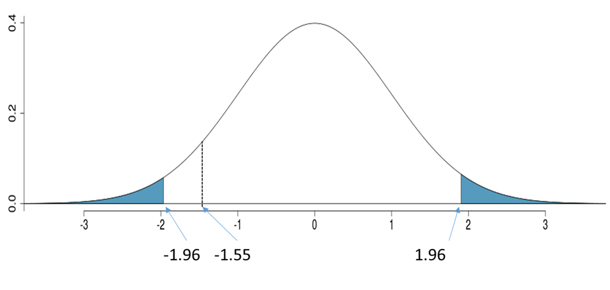

Therefore, fail to reject null hypothesis!

*p-Value Approach*

Derive the p-value associated with the test statistic

Is the test statistic in the lower or upper part of the distribution? $z=-1.55$…therefore lower

```r
pnorm(-1.55,0,1)*2
```

```
## [1] 0.1211415
```

Compare the derived p-value for the test statistic against the level of significance (0.05)

$$p-value = 0.1211 > 0.05$$

Therefore, fail to reject null hypothesis!

*Confidence Interval Approach*

$$\bar{x} = 23.89$$

$$\sigma_{pop} = 2.40$$

$$z_{\frac{\alpha}{2}} = 1.96$$

$$MOE_z = z_{\frac{\alpha}{2}}\frac{\sigma}{\sqrt{n}} = 1.96(\frac{2.40}{\sqrt{30}})=0.8588$$

$$CI_{95} = \bar{x} \pm MOE = 23.89 \pm 0.8588 = (23.03, 24.75)$$

Does the 95% confidence interval contain the hypothesized $\mu_0 = 24.57$? Yes!

Therefore, fail to reject null hypothesis!

*Computational Approach*

```r
xbar <- 23.89                    # sample mean
mu0 <- 24.57                     # hypothesized population mean
sd0 <- 2.40                      # known standard deviation of the population
n <- 30                          # sample size

alpha <- 0.05                    # level of significance
z <- (xbar-mu0)/(sd0/sqrt(n))    # derive test statistic, z
z
```

```
## [1] -1.551881
```

```r
cv <- c(-1.96, 1.96)             # critical values for two sided test with alpha = 0.05

p <- pnorm(z,0,1)*2              # determine p-value associated with test statistic, z
p
```

```
## [1] 0.1206908
```

```r
ci <- xbar + cv*(sd0/sqrt(n))    # determine the 95% confidence interval
ci
```

```
## [1] 23.03117 24.74883
```

### Example 2

The time (minutes) it takes students to complete any given statistics exam is normally distributed with population mean 120 minutes. A sample of 5 observations were taken from a class of undergraduate statistics students recording how long it took them to complete their final exam. The data is given in the table below. One believes that the true population mean of 120 is actually too high. Using the sample data, test the hypothesis using all hypothesis testing methods. You are O.K. with having a Type I error rate of 0.05.

| 1 | 2 | 3 | 4 | 5 |
| --- | --- | --- | --- | --- |
| 121 | 116 | 110 | 114 | 105 |

*Hypothesis*:

$$H_0: \mu \geq 120$$
$$H_A: \mu < 120$$

*Sample Statistics*

$$\bar{x} = \frac{121+116+110+114+105}{5} = 113.2$$
$$s = \sqrt{\frac{(121-113.2)^2+(116-113.2)^2+(110-113.2)^2+(114-113.2)^2+(105-113.2)^2}{5-1}}=6.06$$

```r
samp1 <- c(121, 116, 110, 114, 105)
mean(samp1)
```

```
## [1] 113.2
```

```r
sd(samp1)
```

```
## [1] 6.058052
```

*Critical Value Approach*

Derive Test Statistic ($t$)

$$t=\frac{\bar{x}-\mu_0}{\frac{\sigma}{\sqrt{n}}}$$
$$t=\frac{113.2-120}{\frac{6.06}{\sqrt{5}}} = -2.509$$

Derive Critical Value

```r
qt(0.05, 4)
```

```
## [1] -2.131847
```

Use table given above…

$$t_{(\alpha = 0.05, df=4)} = -2.13$$

$$t (-2.509) \leq cv_{0.05} (-2.13)$$

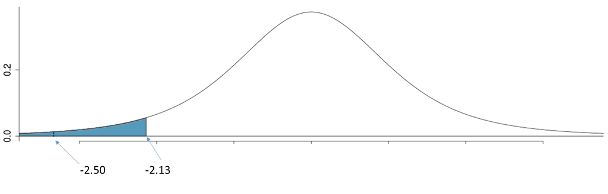

Therefore, reject null hypothesis!

*p-Value Approach*

Derive the p-value associated with the test statistic

Is the test statistic in the lower or upper part of the distribution? $t=-2.509$…therefore lower

```r
pt(-2.509,4)
```

```
## [1] 0.03306395
```

Compare the derived p-value for the test statistic against the level of significance (0.05)

$$p-value = 0.033 < 0.05$$

Therefore, reject null hypothesis!

*Confidence Interval Approach*

$$\bar{x} = 113.2$$

$$s = 6.06$$

$$t_{(\alpha = 0.05, df=4)} = -2.13$$

$$MOE_t = t_{(\alpha = 0.05, df=4)}\frac{s}{\sqrt{n}} = 2.13(\frac{6.06}{\sqrt{5}})=5.7725$$

$$CI_{95} = \bar{x} \pm MOE =113.2 \pm 5.77 = (107.43, 118.97)$$

Does the 95% confidence interval contain the hypothesized $\mu_0 = 120$? No!

Therefore, reject null hypothesis!

*Computational Approach*

```r
samp1 <- c(121, 116, 110, 114, 105)
t.test(samp1, alternative = "less", mu = 120, conf.level = 0.95)
```

```
##
##  One Sample t-test
##
## data:  samp1
## t = -2.5099, df = 4, p-value = 0.03303
## alternative hypothesis: true mean is less than 120
## 95 percent confidence interval:
##      -Inf 118.9757
## sample estimates:
## mean of x
##     113.2
```